# Tarea 6: regularización ridge

En este ejemplo trabajaremos con un [ejemplo de Kaggle](https://www.kaggle.com/c/house-prices-advanced-regression-techniques), en donde queremos predecir el precio listado de una casa dependiendo de varias características.

El diccionario de datos está en el archivo *data_description.txt*

```r
library(tidyverse)
library(glmnet)
datos <- read_csv("./datos/data_train.csv", na= "") %>%
    select(-GarageYrBlt, -LotFrontage, -MasVnrArea, -GarageYrBlt, -MoSold, -PoolQC)
datos$MSSubClass <- factor(datos$MSSubClass)
```

### Preprocesamiento

Necesitamos hacer varios pasos de limpieza y preprocesamiento de datos. Aquí solo haremos una limpieza y transformación parcial para propósitos de nuestro ejemplo.

En primer lugar, nota que muchas de estas variables son categóricas. En los casos donde hay datos no disponibles (NA), estas se cuentan como una categoría más, por ejemplo:

```r
table(datos$Alley)
```

```
Grvl   NA Pave
  50 1369   41
```

En este caso, la categoría NA indica que la casa no tiene acceso por callejón. Igual que en el ejemplo del Titanic, convertimos estas variables con *dummy coding*, o *one hot encoding*.

Podemos usar la función *model.matrix* para hacer este preprocesamiento:

```r
x_datos <- model.matrix(SalePrice ~ ., datos %>% select(-Id))
x_datos <- x_datos[, -1] # quitamos columna de unos
y <- datos$SalePrice
```

Por ejemplo, la variable categórica *Alley* (con 3 niveles) corresponde ahora a dos columnas de variables binarias:

```r
x_datos[c(20,21,22,31), c('AlleyNA','AlleyPave')]
```

```
   AlleyNA AlleyPave
20       1         0
21       1         0
22       0         0
31       0         1
```

que puedes comparar con la variable original

```r
datos[c(20,21,22,31), "Alley"]
```

| Alley |
| --- |
| NA |
| NA |
| Grvl |
| Pave |

Otro ejemplo es la variable *MSZoning*, cuyas categorías son:

```r
table(datos$MSZoning)
```

```
C (all)      FV      RH      RL      RM
     10      65      16    1151     218
```

y corresponde a las nuevas variables

```r
x_datos[1:10, 15:18]
```

```
   MSZoningFV MSZoningRH MSZoningRL MSZoningRM
1           0          0          1          0
2           0          0          1          0
3           0          0          1          0
4           0          0          1          0
5           0          0          1          0
6           0          0          1          0
7           0          0          1          0
8           0          0          1          0
9           0          0          0          1
10          0          0          1          0
```

Aquí mostramos las variables que usaremos para nuestros modelos:

```r
colnames(x_datos)
```

```
  [1] "MSSubClass30"         "MSSubClass40"         "MSSubClass45"
  [4] "MSSubClass50"         "MSSubClass60"         "MSSubClass70"
  [7] "MSSubClass75"         "MSSubClass80"         "MSSubClass85"
 [10] "MSSubClass90"         "MSSubClass120"        "MSSubClass160"
 [13] "MSSubClass180"        "MSSubClass190"        "MSZoningFV"
 [16] "MSZoningRH"           "MSZoningRL"           "MSZoningRM"
 [19] "LotArea"              "StreetPave"           "AlleyNA"
 [22] "AlleyPave"            "LotShapeIR2"          "LotShapeIR3"
 [25] "LotShapeReg"          "LandContourHLS"       "LandContourLow"
 [28] "LandContourLvl"       "UtilitiesNoSeWa"      "LotConfigCulDSac"
 [31] "LotConfigFR2"         "LotConfigFR3"         "LotConfigInside"
 [34] "LandSlopeMod"         "LandSlopeSev"         "NeighborhoodBlueste"
 [37] "NeighborhoodBrDale"   "NeighborhoodBrkSide"  "NeighborhoodClearCr"
 [40] "NeighborhoodCollgCr"  "NeighborhoodCrawfor"  "NeighborhoodEdwards"
 [43] "NeighborhoodGilbert"  "NeighborhoodIDOTRR"   "NeighborhoodMeadowV"
```

[output cut: 74 more lines]

Finalmente, la variable que queremos predecir es *SalePrice*:

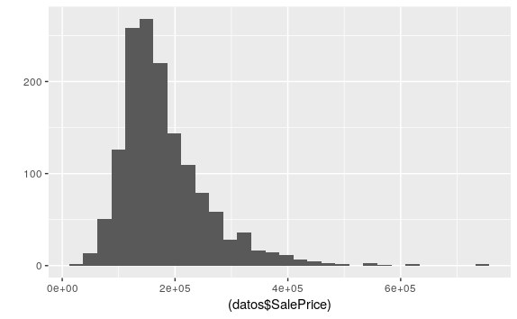

```r
qplot((datos$SalePrice))
```

**Nota: veremos más adelante más pasos de preprocesamiento para mejorar considerablemente el modelo que obtenemos abajo.**

### Regresión ridge

Separamos un conjunto de entrenamiento y uno de prueba (1/2 aproximadamente)

```r
set.seed(9911)
indices_entrena <- sample(1:nrow(x_datos), 700)
x_ent <- x_datos[indices_entrena, -1] # primera columna es de 1's, la quitamos
y_ent <- y[indices_entrena] / 1000 # miles de dólares
x_pr <- x_datos[-indices_entrena, -1]
y_pr <- y[-indices_entrena] / 1000 #miles de dólares
```

1. Utiliza la función glmnet para ajustar modelos lineales para valores de regularización. Utiliza la siguiente sucesión de valores $\lambda$ de regularización ridge:

```r
lambda <- exp(seq(-10, 10, 1))
lambda
```

```
 [1] 4.539993e-05 1.234098e-04 3.354626e-04 9.118820e-04 2.478752e-03
 [6] 6.737947e-03 1.831564e-02 4.978707e-02 1.353353e-01 3.678794e-01
[11] 1.000000e+00 2.718282e+00 7.389056e+00 2.008554e+01 5.459815e+01
[16] 1.484132e+02 4.034288e+02 1.096633e+03 2.980958e+03 8.103084e+03
[21] 2.202647e+04
```

```r
# completa los parámetros que faltan para ajustar los modelos:
mod_ridge <- glmnet(y =y_ent , x = x_ent, alpha = 0, family = "gaussian",
                lambda = lambda)
```

Grafica la traza de los coeficientes:

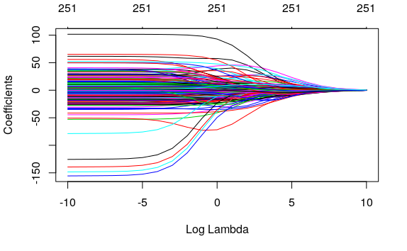

```r
plot(mod_ridge, xvar= "lambda")
```

- ¿Qué pasa con los coeficientes cuando aumenta el valor de lambda?

Cuando el valor de lambda aumenta, el valor de los coeficientes tiende a cero.

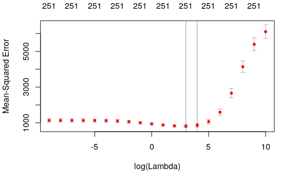

```r
# completa los parámetros que faltan:
cv_mod_1 <- cv.glmnet(y = y_ent, x = x_ent, alpha = 0, family = "gaussian",
                      lambda = lambda, nfolds = 10)
plot(cv_mod_1)
```

```r
cv_mod_1$lambda.min
```

```
[1] 20.08554
```

```r
cv_mod_1$lambda.1se
```

```
[1] 54.59815
```

¿Qué valores de la regularización dan los errores más bajos (según la estimación de validación cruzada?)

Cuando lambda es 20.08554 se obtiene el error más bajo, otro valor de lambda que se puede tomar es 54.59815

3. Selecciona un modelo con baja regularización, con el valor óptimo según validación cruzada, y otro con mucha regularización (utiliza las lambdas mostradas abajo). Evalúa el error de predicción (raíz de error cuadrático media) según la muestra de prueba que separamos arriba:

```r
# rellena tres valores, uno con muy baja regularización , uno con regularización
#óptima según validación cruzada, y otro con demasiada regularización:
lambda_pred <- c(lambda[1] , cv_mod_1$lambda.min, lambda[21])
lambda_pred
```

```
[1] 4.539993e-05 2.008554e+01 2.202647e+04
```

Calcula errores de prueba

```r
preds_1 <- predict(mod_ridge, newx = x_pr, s = lambda_pred[1])
preds_2 <- predict(mod_ridge, newx = x_pr, s = lambda_pred[2])
preds_3 <- predict(mod_ridge, newx = x_pr, s = lambda_pred[3])
sqrt(mean((preds_1 - y_pr)^2))
```

```
[1] 41.21686
```

```r
sqrt(mean((preds_2 - y_pr)^2))
```

```
[1] 36.18995
```

```r
sqrt(mean((preds_3 - y_pr)^2))
```

```
[1] 74.67852
```

- ¿Qué modelo tiene el error más bajo de prueba? ¿Por qué esperarías esto? El modelo con error de prueba más bajo es el dado por la lambda mínima otenida por cross validation. Esto es esperado por que una regularización baja equivale a no regularizar, mientras que una regularización alta equivale a que los coeficientes de las variables sean cero.

Grafica predicciones del modelo con menor error contra los valores observados

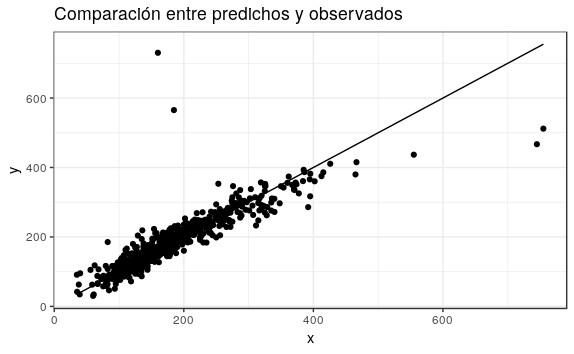

```r
ggplot()+theme_bw()+
  geom_line(aes(y_pr,y_pr))+
  geom_point(aes(y_pr,preds_2))+
  ggtitle("Comparación entre predichos y observados")+
  xlab("x")+ylab("y")+
  theme(legend.title = element_blank())
```

```r
NA
```

4. Compara los coeficientes del modelo menos regularizado con el de regularización óptima

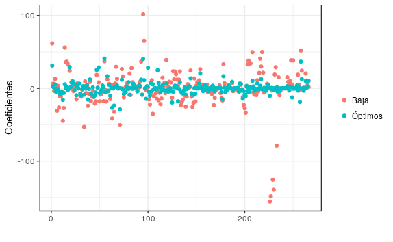

```r
coefs_reg_baja <- predict(mod_ridge,
                          s = lambda_pred[1], type= "coefficients")
coefs_reg_baja <- coefs_reg_baja[-1,1] # tomamos la primera columna y quitamos intercept
# rellena aquí
coefs_reg_opt <- predict(mod_ridge,
                          s = lambda_pred[2], type= "coefficients")
coefs_reg_opt <- coefs_reg_opt[-1,1] #

# ahora grafica estos coeficientes en una gráfica x-y:
ggplot()+theme_bw()+
  geom_point(aes(1:266,coefs_reg_baja, col="Baja"))+
  geom_point(aes(1:266,coefs_reg_opt, col="Óptimos"))+
  ylab("Coeficientes")+xlab("")+
  theme(legend.title = element_blank())
```

```r
summary(coefs_reg_baja)
```

```
      Min.    1st Qu.     Median       Mean    3rd Qu.       Max.
-155.57634   -6.60853    0.01945   -0.04454    8.06021  101.62588
```

```r
summary(coefs_reg_opt)
```

```
    Min.  1st Qu.   Median     Mean  3rd Qu.     Max.
-28.9770  -3.4031   0.0000   0.2274   2.5885  40.7786
```

- ¿Qué puedes decir acerca de la dispersión de los coeficientes del modelo con baja regularización en comparación al de regularización media? ¿Cuál es el rango de los coeficientes del modelo con baja regularización? El rango de los coeficientes con regularización baja va desde -155.57 hasta 101.62, mientras que con regularización óptima están entre -28.97 y 40.77. Por lo que la dispersión de los datos con regularización baja es mucho mayor.
5. Compara algunos coeficientes de dos modelos, el de regularización baja con uno de regularización óptima según validación cruzada

Por ejemplo, compara los coeficientes relacionados con el garage (tipo, terminados, Calidad, Condición, coches y área):

```r
coefs_reg_baja <- predict(mod_ridge,
                          s = lambda_pred[1], type= "coefficients")
nombres <- rownames(coefs_reg_baja)
coef_garage_baja <- coefs_reg_baja[, 1][str_detect(nombres, "Garage")]
coefs_reg_opt <- predict(mod_ridge,
                          s = lambda_pred[2], type= "coefficients")
nombres <- rownames(coefs_reg_opt)
coef_garage_opt <- coefs_reg_opt[, 1][str_detect(nombres, "Garage")]
cbind(coef_garage_baja, coef_garage_opt)
```

```
                  coef_garage_baja coef_garage_opt
GarageTypeAttchd       21.24896876     -0.78930137
GarageTypeBasment      40.79019651      3.50213541
GarageTypeBuiltIn      29.94498859     12.55401685
GarageTypeCarPort      49.91936118     -1.41474531
GarageTypeDetchd       21.44514445     -1.17099538
GarageTypeNA           -5.80134652      0.54143947
GarageFinishNA         -2.36802984      0.40821875
GarageFinishRFn        -0.52328638     -3.42375026
GarageFinishUnf         6.14203771      0.22565270
GarageCars              3.76889437      5.23678591
GarageArea              0.02424743      0.02446150
GarageQualFa         -155.57634386    -10.38174172
GarageQualGd         -148.33127869     -0.51798200
GarageQualNA           -3.06087570      0.67002108
GarageQualPo         -125.60618178      0.06108298
GarageQualTA         -139.37714948     -2.67174662
GarageCondFa           18.90792107     -0.01802216
GarageCondGd           28.96223486     -1.80195503
GarageCondNA          -78.70272545      0.93576449
GarageCondPo            1.80192796     -4.66634123
GarageCondTA           15.13592088     -0.17737488
```

- ¿Qué efecto puede tener esta variable en tus predicciones? Considera que el tamaño de los coeficientes está en miles de dólares? Que una ligera mejora en alguna de las variables de calidad se traduciría en una disminución de 155 mil dólares del precio de la casa, lo cual no tiene mucho sentido.
- ¿Cuál es el valor mediano de las casas en el conjunto de entrenamiento (y)? ¿Los efectos del inciso anterior te parecen razonables?

```r
median(y)
```

```
[1] 163000
```

```r
coef_garage_baja*1000/median(y)
```

```
 GarageTypeAttchd GarageTypeBasment GarageTypeBuiltIn GarageTypeCarPort
     0.1303617715      0.2502466043      0.1837115865      0.3062537495
 GarageTypeDetchd      GarageTypeNA    GarageFinishNA   GarageFinishRFn
     0.1315653034     -0.0355910829     -0.0145277904     -0.0032103459
  GarageFinishUnf        GarageCars        GarageArea      GarageQualFa
     0.0376812129      0.0231220514      0.0001487572     -0.9544560973
     GarageQualGd      GarageQualNA      GarageQualPo      GarageQualTA
    -0.9100078447     -0.0187783785     -0.7705900723     -0.8550745367
     GarageCondFa      GarageCondGd      GarageCondNA      GarageCondPo
     0.1159995158      0.1776824224     -0.4828388065      0.0110547728
     GarageCondTA
     0.0928584103
```

Ahora para regularización óptima según validación cruzada:

```r
coef_garage_opt*1000/median(y)
```

```
 GarageTypeAttchd GarageTypeBasment GarageTypeBuiltIn GarageTypeCarPort
    -0.0048423397      0.0214854933      0.0770185083     -0.0086794191
 GarageTypeDetchd      GarageTypeNA    GarageFinishNA   GarageFinishRFn
    -0.0071840207      0.0033217145      0.0025044095     -0.0210046028
  GarageFinishUnf        GarageCars        GarageArea      GarageQualFa
     0.0013843724      0.0321275209      0.0001500706     -0.0636916670
     GarageQualGd      GarageQualNA      GarageQualPo      GarageQualTA
    -0.0031778037      0.0041105588      0.0003747422     -0.0163910836
     GarageCondFa      GarageCondGd      GarageCondNA      GarageCondPo
    -0.0001105654     -0.0110549388      0.0057408864     -0.0286278603
     GarageCondTA
    -0.0010881895
```

- ¿Qué efecto puede tener esta variable en tus predicciones? Considera que el tamaño de los coeficientes está en miles de dólares? Los cambios son más razonables que en el modelo anterior, sí modifican el precio de la casa, pero no desproporciondamente
- ¿Cuál es el valor mediano de las casas en el conjunto de entrenamiento (y)? ¿Los efectos del inciso anterior te parecen razonables?